# PML Assignment

## Synopsis

The quantified self movement devices are able to collect a large amount of data about personal activity relatively inexpensively. The goal is to find patterns in physical behavior leading to health improvement. This study uses data from accelerometers on the belt, forearm, arm, and dumbell of 6 participants (the data set is provided by http://groupware.les.inf.puc-rio.br/har). They were asked to perform barbell lifts correctly and incorrectly in 5 different ways. The purpose of this study is to predict the manner in which they did the exercise. The classification variable is *classe* having 5 possible outcomes (A, B, C, D and E).

## Data Processing

### Raw Data

The dataset is provided by [Groupware@LES](http://groupware.les.inf.puc-rio.br/har), aiming human activity recognition. The downloaded file pml-training.csv is used in R script in order to do the analysis.

### Cleaning and Preprocessing data

The following preprocessing actions are considered:

1. the data from accelerometers on the belt, forearm, arm, and dumbell will be extracted from the data set
2. the NA based columns will be removed as well
3. check for near zero variance predictors

```r
  #read one row of data to decide which columns are eligible
  headcols = read.csv('pml-training.csv', nrows = 1, na.strings = c('', 'NA', 'NULL'))
  #name based filtering
  #remove NA based columns
  cols = dim(headcols)[2]
  colClass = rep('NULL', cols)
  colClass[intersect(grep('belt|forearm|arm|dumbbell', names(headcols)), col(headcols)[!is.na(headcols)])] = 'numeric'
  #the outcome is classe column
  colClass[cols] = 'character'
  #read the entire data set
  tr = read.csv('pml-training.csv', header = TRUE, colClasses = colClass, na.strings = c('', 'NA', 'NULL'))
  #check predictors having near zero variance
  nzv = nearZeroVar(tr, saveMetrics = FALSE)
```

There is no near zero variance predictors, so the preprocessed data set has 19622 rows and 53 cols.

## Prediction Model

The dimensions of the final data set reveal a medium size, thus the partition rule: *60% for training and 40% for validation* is considered for the current study.

```r
  set.seed(12345)
  trainidx = createDataPartition(y = tr$classe, p=0.6, list=FALSE)
  trainds = tr[trainidx,]
  validds = tr[-trainidx,]
```

The out of sample (generalization) error is computed as 1 - accuracy given by the comparison between the validation data set *classe* values and the predicted ones. The expected out of sample error value should be less than 5% (the accuracy should be greater than 95%).

Cross validation is the simplest and widely method for estimating out of sample error. K-fold cross validation selects K folds, meaning that the classification algorithm groups the data into K subsamples, estimating K-1 models where one model is saved as the hold out group while the remaining K-1 subsamples are used to train the model. The results are aggregated in order to create an overall estimate of the out of sample error.

Bootstrap is a general tool for assessing statistical accuracy, estimating extra-sample prediction error.

The outcome *classe* is a discrete variable, a categorical one. This recommends the classification tree algorithms for the prediction model fitting. The following cases are considered to build the prediction model: classification trees and random forests.

### Classification Trees

Model fitting is using recursive partitioning method.

```r
  #model fitting
  mod_ct = train(classe ~ ., method = 'rpart', data = trainds)
  #predict new values
  pred = predict(mod_ct, newdata = validds)
  #evaluate the accuracy
  cm = confusionMatrix(validds$classe, pred)
  #show tree info
  print(mod_ct$finalModel)
```

```
## n= 11776
##
## node), split, n, loss, yval, (yprob)
##       * denotes terminal node
##
##  1) root 11776 8428 A (0.28 0.19 0.17 0.16 0.18)
##    2) roll_belt< 130.5 10799 7457 A (0.31 0.21 0.19 0.18 0.11)
##      4) pitch_forearm< -33.95 945    8 A (0.99 0.0085 0 0 0) *
##      5) pitch_forearm>=-33.95 9854 7449 A (0.24 0.23 0.21 0.2 0.12)
##       10) yaw_belt>=169.5 495   47 A (0.91 0.038 0 0.051 0.0061) *
##       11) yaw_belt< 169.5 9359 7107 B (0.21 0.24 0.22 0.2 0.13)
##         22) magnet_dumbbell_z< -93.5 1118  467 A (0.58 0.29 0.046 0.055 0.029) *
##         23) magnet_dumbbell_z>=-93.5 8241 6238 C (0.16 0.23 0.24 0.22 0.14)
##           46) pitch_belt< -42.95 500   79 B (0.018 0.84 0.094 0.026 0.02) *
##           47) pitch_belt>=-42.95 7741 5785 C (0.17 0.19 0.25 0.24 0.15)
##             94) accel_forearm_x>=-99.5 4688 3417 C (0.21 0.22 0.27 0.12 0.18) *
##             95) accel_forearm_x< -99.5 3053 1776 D (0.096 0.16 0.22 0.42 0.1) *
##    3) roll_belt>=130.5 977    6 E (0.0061 0 0 0 0.99) *
```

The tree is not large, it has just 7 levels. As a consequence, there is not need to prune or use ‘early stopping’ method. The accuracy 0.4993627 value is quite low, thus the model performs poorly. The out of sample error rate is 0.5006373.

### Random Forests

This method trains two models using *bootstrap* and *cross validation* as resampling methods.

Tune model using resampling method *bootstrap* using 5 iterations:

```r
  fitCtrl = trainControl(method = "boot", number = 5, allowParallel = T, verbose = F)
  mod_rf_b = train(classe ~ ., method = 'rf', data = trainds, trControl = fitCtrl, verbose = F)
  #predict new values
  pred = predict(mod_rf_b, newdata = validds)
  #evaluate the accuracy
  cm_rf_b = confusionMatrix(validds$classe, pred)
```

The accuracy 0.9923528 value is higher than 90%. The out of sample error rate is 0.0076472.

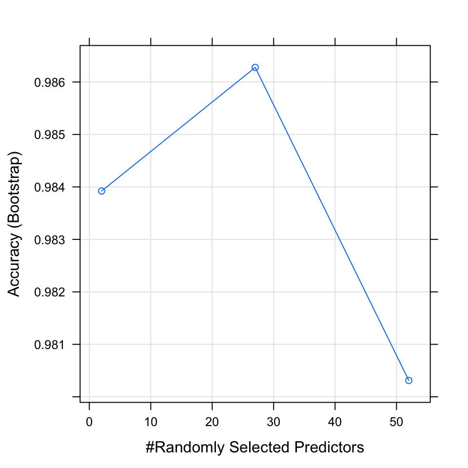

```r
  plot(mod_rf_b)
```

The random forests model with 27 predictors is selected by the best accuracy.

Tune model using resampling method *cross validation* to select the number of the predictors. The number of folds is 5 due the computational cost.

```r
  fitCtrl = trainControl(method = "cv", number = 5, allowParallel = T, verbose = F)
  mod_rf_cv = train(classe ~ ., method = 'rf', data = trainds, trControl = fitCtrl, verbose = F)
  #predict new values
  pred = predict(mod_rf_cv, newdata = validds)
  #evaluate the accuracy
  cm = confusionMatrix(validds$classe, pred)
```

The accuracy 0.9924802 value is higher than 90%. The out of sample error rate is 0.0075198.

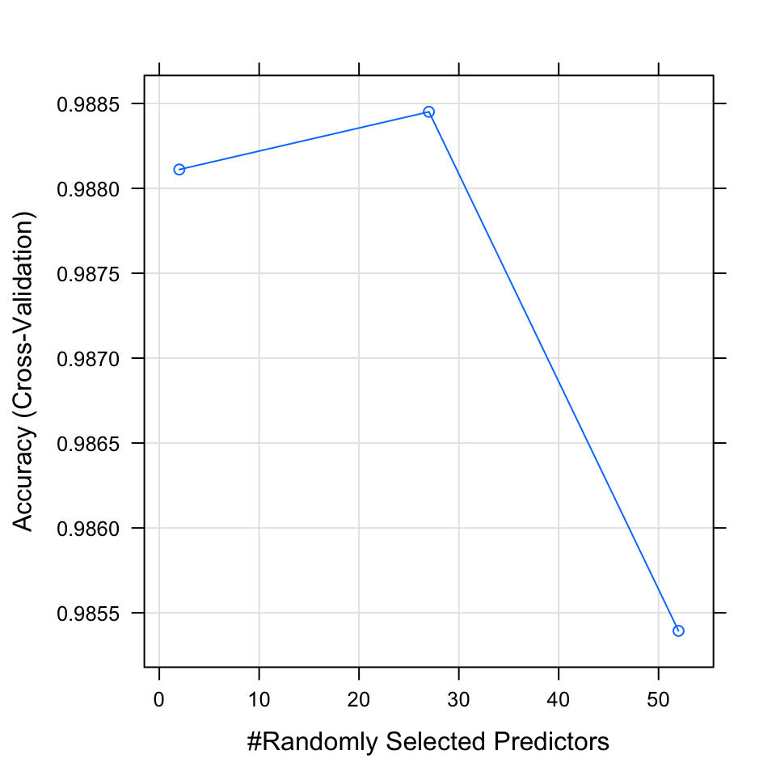

```r
  plot(mod_rf_cv)
```

The random forests model with 27 predictors is selected by the best accuracy.

## Testing

A separate data set for testing pml-testing.csv is used in R script in order to do the testing.

```r
  tst = read.csv('pml-testing.csv', header = TRUE, colClasses = colClass, na.strings = c('', 'NA', 'NULL'))
  pred = predict(mod_rf_cv, newdata = tst)

  pred
```

```
##  [1] B A B A A E D B A A B C B A E E A B B B
## Levels: A B C D E
```